# 2018 Ford GoBike System Data

## Investigation Overview

> In this investigation, the behavior of subscribers and customers was analyzed. The main focus was on the daily, hourly, and monthly travel distance and duration between customers and subscribers.

## Dataset Overview

> This data set includes information about individual rides made in a bike-sharing system covering the greater San Francisco Bay area (San Francisco, East Bay, San Jose). This dataset requires some data wrangling in order to make it tidy for analysis. There are multiple data files that will need to be joined together for a full year’s coverage. The combined 2018 Ford GoBike System Data contains 1,863,721 trips. 156,703 points were removed from the analysis due to inconsistencies.

```python
# import all packages and set plots to be embedded inline
import numpy as np
import pandas as pd
import matplotlib.pyplot as plt
import seaborn as sb
import datetime
from haversine import haversine, Unit
import glob

%matplotlib inline

# suppress warnings from final output
import warnings
warnings.simplefilter("ignore")
```

```python
# load in the dataset into a pandas dataframe
all_files= glob.glob('*fordgobike-tripdata.csv')

list_file = []

for file in all_files:
    df = pd.read_csv(file, index_col=None, header=0)
    list_file.append(df)

df = pd.concat(list_file, sort=True, axis=0, ignore_index=True)
```

> Note that the above cells have been set as "Skip"-type slides. That means that when the notebook is rendered as http slides, those cells won't show up.

## User Type

> An overwhelming number of users are subscribers (87.7%).

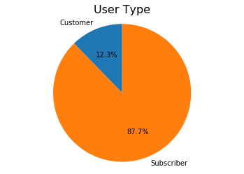

## Trip Duration vs Trip Distance

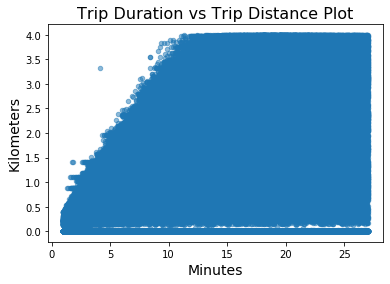

## Monthly Bike Ride Trend

> Overall, the monthly bike rides for customers increase then plateaus in May and then decreases. However, the monthly bike rides gradually increases and plateaues, peaking in October, and followed by a dramatic drop in November and December.

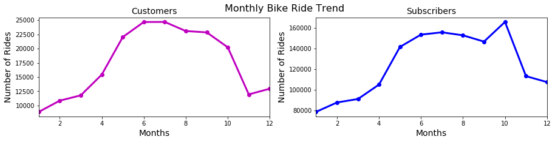

## Hourly Bike Ride Trend

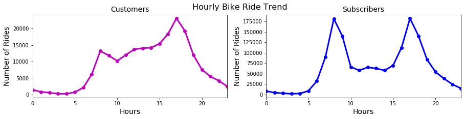

## Daily Bike Ride Trend

> The weekend is popular for customers unlike subscribers. Moreover, the weekend is the least popular time for subscribers. Tuesday is the most popular, followed by Wednesday and Thursday among the subscribers. Saturday is the most popular day, followed by Friday and Sunday among the Customers.

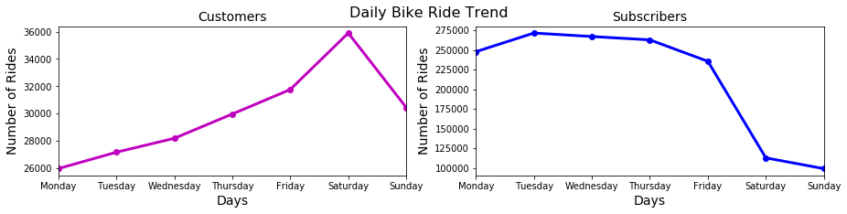

## Average Monthly Trip Distance

> The average monthly trip distance is similar, but customers have slightly higher averages.

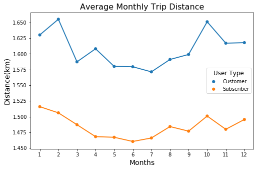

## Average Hourly Trip Distance

> The average hourly trip distance is similar, but customers have slightly higher averages.

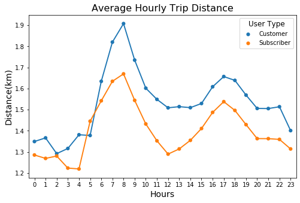

## Average Daily Trip Distance

> The average daily trip distance is similar, but customers have slightly higher averages even during the weekend.

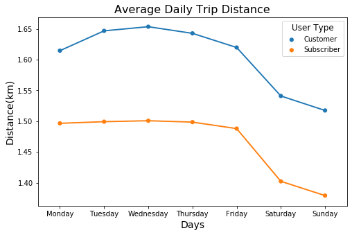

## Most Frequently Used Daily Trip Durations During Peak Hours

> The most frequently used trips last 5-10 minutes during the weekdays among customers and subscribers. Moreover, customers have similar trip durations to subscribers during the weekend although customers tend to be the most active at that time.

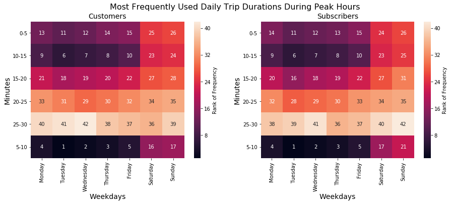

## Most Frequently Used Monthly Trip Durations During Peak Hours

> The most frequently used trips last 5-10 minutes from April through October among customers and subscribers.

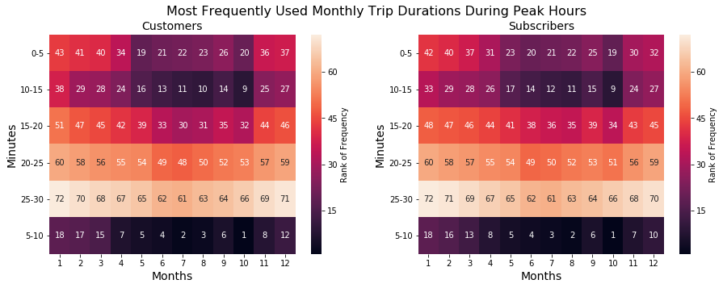

## Most Frequently Used Daily Trip Distance During Peak Hours

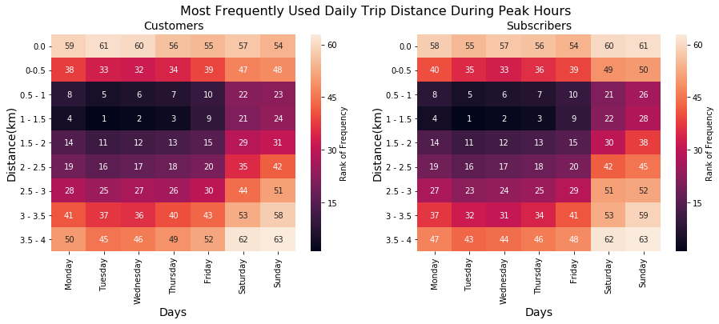

## Most Frequently Used Monthly Trip Distance During Peak Hours

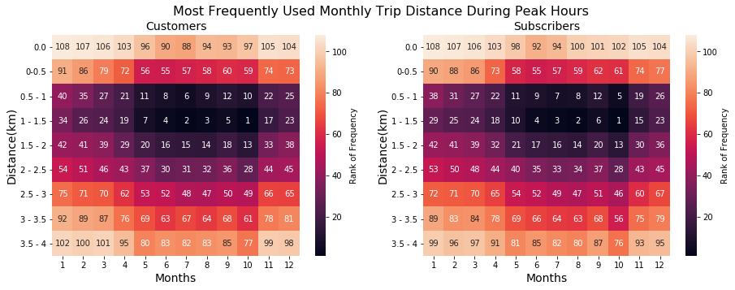

> Once you're ready to finish your presentation, check your output by using nbconvert to export the notebook and set up a server for the slides. From the terminal or command line, use the following expression:

> > `jupyter nbconvert <file_name>.ipynb --to slides --post serve --template output_toggle`

> This should open a tab in your web browser where you can scroll through your presentation. Sub-slides can be accessed by pressing 'down' when viewing its parent slide. Make sure you remove all of the quote-formatted guide notes like this one before you finish your presentation!